W ocenie modelu liniowego pomoże nam statystyka R2, zwana współczynnikiem determinacji, i zdefiniowana jako wariancja zmiennej Y wyjaśniona przez nasz model:
$$R^2 = \frac{\sum_{i=1}^n (\hat{y}_i - \bar{y}_i)^2}{\sum_{i=1}^n (y_i - \bar{y}_i)^2}.$$

*Zadanie5* Załaduj dane anscombe za pomocą komendy data(anscombe). Dane mają postać macierzy z kolumnami $x_i$ oraz $y_i$ dla $i=1,2,3,4$ Następnie: * Utwórz cztery modele linowe $y_i \sim x_i$ * Porównaj współczynniki determinacji tych modeli. Współczynniki możesz znaleźć korzystając z funkcji summary. * Przedstaw zależność pomiędzy yi a xi na wykresie, i zaznacz na nim prostą regresji. Czy wszystkie modele są tak samo dobre?

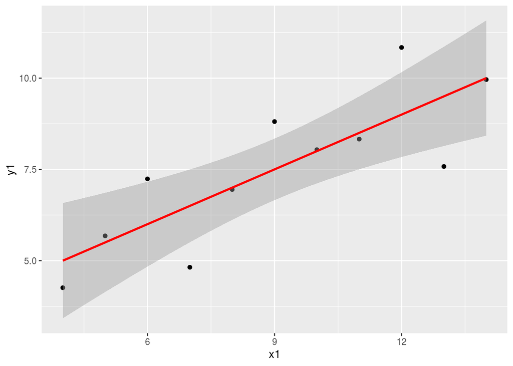

```r
data(anscombe)
attach(anscombe)
library(ggplot2)

m1 <- lm(y1 ~ x1)


ggplot(anscombe, aes(x = x1, y = y1)) +
  geom_point() +
  stat_smooth(method = "lm", col = "red")
```

```r
summary(m1)# Multiple R-Square: 0.6665
```

```
##
## Call:
## lm(formula = y1 ~ x1)
##
## Residuals:
##      Min       1Q   Median       3Q      Max
## -1.92127 -0.45577 -0.04136  0.70941  1.83882
##
## Coefficients:
##             Estimate Std. Error t value Pr(>|t|)
## (Intercept)   3.0001     1.1247   2.667  0.02573 *
## x1            0.5001     0.1179   4.241  0.00217 **
## ---
## Signif. codes:  0 '***' 0.001 '**' 0.01 '*' 0.05 '.' 0.1 ' ' 1
##
## Residual standard error: 1.237 on 9 degrees of freedom
## Multiple R-squared:  0.6665, Adjusted R-squared:  0.6295
## F-statistic: 17.99 on 1 and 9 DF,  p-value: 0.00217
```

Pierwszy wykres jest prostą regresją linową, widać zależnosć linową danych.

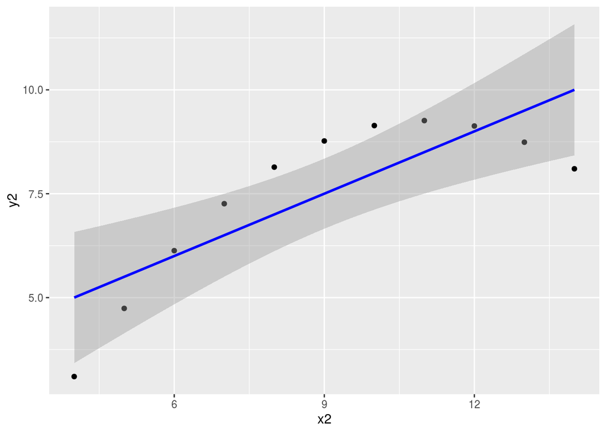

```r
m2 <- lm(y2 ~ x2)

ggplot(anscombe, aes(x = x2, y = y2)) +
  geom_point() +
  stat_smooth(method = "lm", col = "blue")
```

```r
summary(m2)# Multiple R-Square: 0.6662
```

```
##
## Call:
## lm(formula = y2 ~ x2)
##
## Residuals:
##     Min      1Q  Median      3Q     Max
## -1.9009 -0.7609  0.1291  0.9491  1.2691
##
## Coefficients:
##             Estimate Std. Error t value Pr(>|t|)
## (Intercept)    3.001      1.125   2.667  0.02576 *
## x2             0.500      0.118   4.239  0.00218 **
## ---
## Signif. codes:  0 '***' 0.001 '**' 0.01 '*' 0.05 '.' 0.1 ' ' 1
##
## Residual standard error: 1.237 on 9 degrees of freedom
## Multiple R-squared:  0.6662, Adjusted R-squared:  0.6292
## F-statistic: 17.97 on 1 and 9 DF,  p-value: 0.002179
```

Drugi wykres zależność między nimi nie jest linowa. Dane nie pochodzą z rozkładu normalnego

```r
m3 <- lm(y3 ~ x3)
summary(m3)# Multiple R-Square: 0.6663
```

```
##
## Call:
## lm(formula = y3 ~ x3)
##
## Residuals:
##     Min      1Q  Median      3Q     Max
## -1.1586 -0.6146 -0.2303  0.1540  3.2411
##
## Coefficients:
##             Estimate Std. Error t value Pr(>|t|)
## (Intercept)   3.0025     1.1245   2.670  0.02562 *
## x3            0.4997     0.1179   4.239  0.00218 **
## ---
## Signif. codes:  0 '***' 0.001 '**' 0.01 '*' 0.05 '.' 0.1 ' ' 1
##
## Residual standard error: 1.236 on 9 degrees of freedom
## Multiple R-squared:  0.6663, Adjusted R-squared:  0.6292
## F-statistic: 17.97 on 1 and 9 DF,  p-value: 0.002176
```

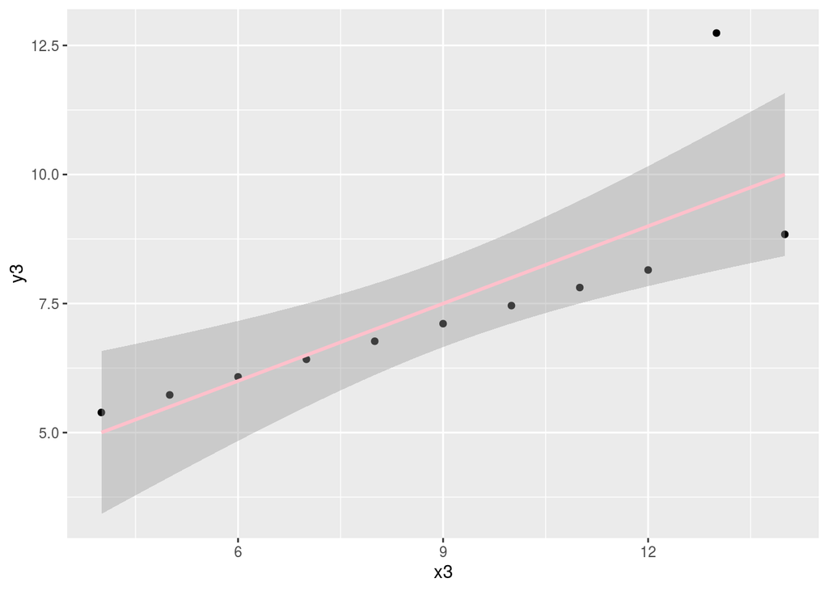

```r
ggplot(anscombe, aes(x = x3, y = y3)) +
  geom_point() +
  stat_smooth(method = "lm", col = "pink")
```

Trzeci wykres, zależność jest linowa, jednak powinniśmy mieć inną prostą regresji. Obecna sytuacja jest spowodowana przez outlier.

```r
m4 <- lm(y4 ~ x4)
summary(m4) # Multiple R-Square: 0.6667
```

```
##
## Call:
## lm(formula = y4 ~ x4)
##
## Residuals:
##    Min     1Q Median     3Q    Max
## -1.751 -0.831  0.000  0.809  1.839
##
## Coefficients:
##             Estimate Std. Error t value Pr(>|t|)
## (Intercept)   3.0017     1.1239   2.671  0.02559 *
## x4            0.4999     0.1178   4.243  0.00216 **
## ---
## Signif. codes:  0 '***' 0.001 '**' 0.01 '*' 0.05 '.' 0.1 ' ' 1
##
## Residual standard error: 1.236 on 9 degrees of freedom
## Multiple R-squared:  0.6667, Adjusted R-squared:  0.6297
## F-statistic:    18 on 1 and 9 DF,  p-value: 0.002165
```

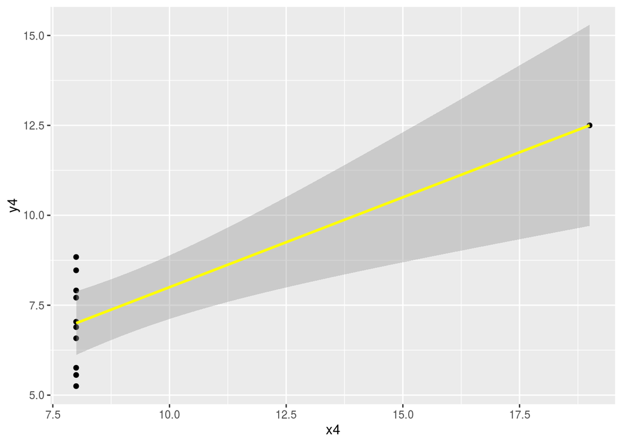

```r
ggplot(anscombe, aes(x = x4, y = y4)) +
  geom_point() +
  stat_smooth(method = "lm", col = "yellow")
```

Czwarty wykres, reprezentuje próbkę w której mamy jednen punkt, który wpływa na współcznnik $\beta_1$, pozostałe punkty nie wskazują na żadne linowe związki między zmiennymi.